# Aggregating Anteaters Project

B155926, B239086, B239979, B244840, and B246814

# 1 Data Preparation

Before starting to describe and analyse the data, we checked that all observations were entered within the possible range of each continuous variable and levels of categorical variables. We inspected visualisations of the marginal distributions of and relationships amongst the variables to identify observations with impossible values (see Figure 5.1 in the Appendix). We excluded all impossible values (e.g., a negative reported frequency of emoji use) along with any observations containing missing data (N<sub>excluded</sub> = 5). Table 5.1 in the Appendix provides an overview of excluded data points and the reason for exclusion. Finally, we corrected ‘Appple’ to ‘Apple’ for operating system of 7 observations.

# 2 Data Description

## 2.1 Difference Between Operating System and Frequency of Emoji Use

We explored whether there’s a difference in the frequency of emoji use between Apple and Android users. We did this in two ways - we created violin plots, and conducted a bootstrapped t-test.

From Figure 2.1, we can see that the lower quartile and median of the two operating systems are very similar. However, the upper quartile is higher and the overall range is larger for Apple than Android. It seems that Apple users are more likely to use a higher number of emojis per day. Android users, however, are more densely concentrated around the median. There are only three unusually high values at 24 emojis per day, all reported by Apple users.

# 2 Data Description and Initial Tests

## 2.1 Difference Between Operating System and Frequency of Emoji Use

First, we investigated if there is a difference in how frequently emojis were used between users of Apple and Android operating systems. Figure 2.1, shows that the lower quartile and median of the two operating systems were similar. However, the upper quartile is higher and the overall range is larger for Apple than Android. It seems that Apple users are more likely to use a higher number of emojis per day. There are only three unusually high values all reported by Apple users.

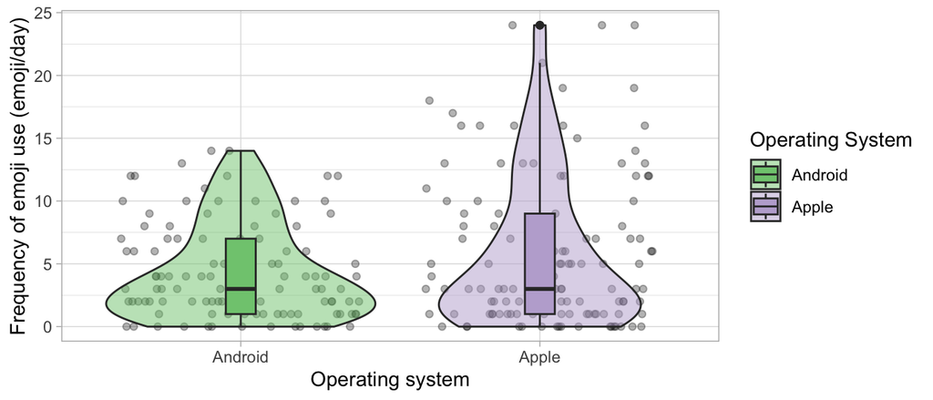

Figure 2.1: Frequency of Emoji Use on Apple and Android Operating System

Initially, we conducted a two-tailed Welch two sample t-test ($\alpha$ = 0.05) to assess whether the mean frequency of emoji use was different between Android (*Android n* = 109 ; *m* = 4.3; *sd* = 3.77) and Apple users (*n* = 126; *m* = 5.87; *sd* = 6.01) while accounting for the unequal variances in the two groups (see sds; supported by F test of the variance ratio; *F*(108, 125) = 0.39, *p* < 0.001). This indicated a significantly higer mean emoji use frequency used Apple users compared to Android users, *t*(213.42) = -2.39, *p* = 0.018, two-tailed). However, this test assumes normally distributed values of frequency of emoji use in each group, which was not the case as shown by Q-Q plots (see appendix, Figure 5.2) and corroborated by Shapiro-Wilks tests indicating significantly non-normal distributions (Android: *W* = 1, *p* = < 0.001; Apple: *W* = 1, *p* = < 0.001). This may affect the estimation of the standard error and, in turn, the reported significance. Given the large sample size (n > 200), we conducted a sensitivity analysis using bootstrapped 95 % confidence intervals, as this way of estimating standard error has no assumptions about normality. The bootstrapped estimated mean frequency of emoji use was 1.55 lower in Android users compared to Apple users (95 % *CI*[-2.76, -0.15]. The non-zero containing confidence interval of this mean difference supports the conclusion from the Welch t-test without the assumption of normal group populations that Apple users indeed used emojis more frequently than Android users.

## 2.2 Correlation Between Age and Frequency of Emoji Use

To assess if there is a relationship between participant age (*m* = 35.39, *sd* = 13.4) and the frequency of their emoji use (*m* = 5.16 (*sd* = 5.13), we planned to conduct a Pearson correlation test. However, upon visualising these variables and their relationship in Figure 2.2, these do not conform to the assumptions of a Pearson correlation coefficient. Firstly, age and frequency seem to co-move in a negative but non-linear fashion. The accompanying histograms reveal that the frequency of emoji and age are not normally distributed, as verified by Shapiro–Wilk tests (Frequency of emoji use: *W* = 0.85, *p* < 0.001; Age: *W* = 0.94, *p* < 0.001) with the former seeming to follow a Poisson distribution while latter is largely uniform. Since normally distributed variables with a linear relationship are assumed for a Pearson correlation test, we conducted a Spearman’s rank correlation test, which tests for a monotonic relationship between two variables without assumptions about the normality of their distributions or the linearity of their relationship.

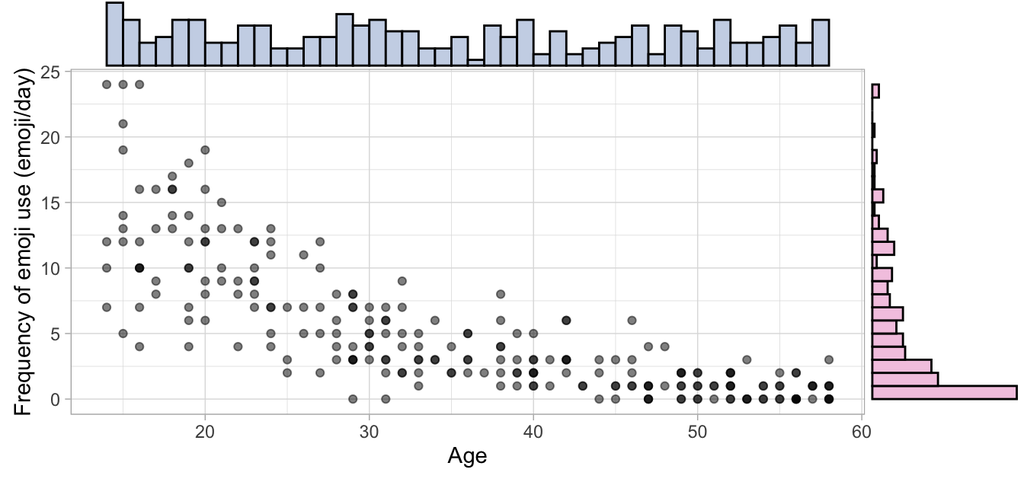

Figure 2.2: Relationship Between Age and Frequency of Emoji Use

The Spearman’s rank correlation test (237) indicated that there was a significant strong negative correlation between age of an individual and the frequency of emoji use (*R* = -0.86, *S* = 4128923.53), *p* < 0.001). Thus, while not linearly, it seems like as age increased, emojis were used less frequently.

## 2.3 Balance of Users of Operating Systems for Emoji Categories

Finally, we investigated whether there is a balance between Apple and Android users for each category of emoji. Figure 2.3 shows the distribution of these operating systems for each emoji category. For all categories, the number of Apple users seem slightly larger than Android users, with the largest difference for the thumbs up emoji (👍). We conducted a $\chi^2$ goodness of fit test for *each* emoji category to test if the observed proportion of participants using each operating system deviated from a hypothesised equal proportion of users (50% each), which would indicate balance.

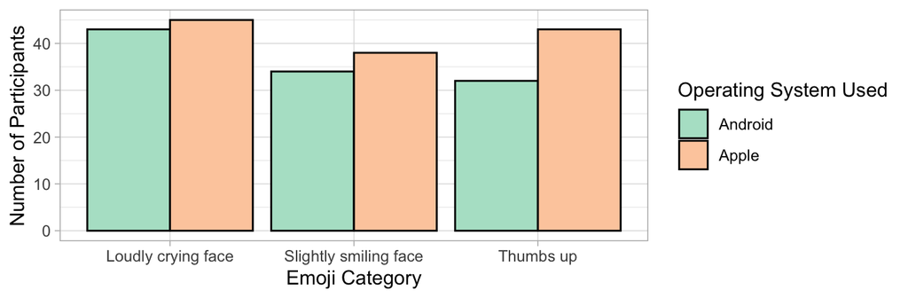

Figure 2.3: Distribution of Participants on Apple and Android Operating System for Each Emoji Category

For each emoji category, we found no significant difference between the observed proportions of Apple and Android users and equal proportions: for loudly crying face emoji (😭) (*n* = 88, *proportion<sub>Apple</sub>* = 51.14 %; $\chi^2$ (1) = 0.05, *p* = 0.831); for the slightly smiling face emoji (🙂) (*n* = 72, *proportion<sub>Apple</sub>* = 52.78 %; $\chi^2$ (1) = 0.22, *p* = 0.637); and for the thumbs up emoji (👍) (*n* = 75, *proportion<sub>Apple</sub>* = 57.33 %, $\chi^2$ (1) = 1.61, *p* = 0.204). Thus, we found no evidence of imbalance of users of Apple and Android operated phones in any of the emoji categories.

# 3 The Emotional Effect of Emojis

The first research aim that we addressed were which factors influenced the emotional valence of emoji. We fitted a multiple regression model with frequency as the initial predictor due to its known effect on emotional valence score, the type of emoji, as well as participant age, and the interaction between age and emoji category to investigate the effect of age on emotional content of emoji and whether this differs between emojis. We mean-centered age (*m* = 35.39) and scaled the emotional valence score by its standard deviation (*sd* = 7.8433763) allowing us to interpret the intercept at the mean age and coefficients as change in terms of standard deviations of emotional valence score. Emoji category was treatment coded with the “loudly crying face” emoji (😭) as the reference level (see 5.2).

Figure 3.1 provides an overview of the predictors, emotional valence score, and their relationships. Emotional valence score was normally distributed (Figure 3.1C). As noted previously, this was not the case for age(Figure 3.1D) and frequency of Emoji use (Figure 3.1E). There were slightly more participants who rated the loudly crying face emoji [😭] than the other emoji categories (Figure 3.1). Figure 3.1B also indicates a negative relationship between age and emotional valence score; as age increases, the emotional valence score decreases. This decrease seem more pronounced in the loudly crying face emoji group [😭] than the other categories.

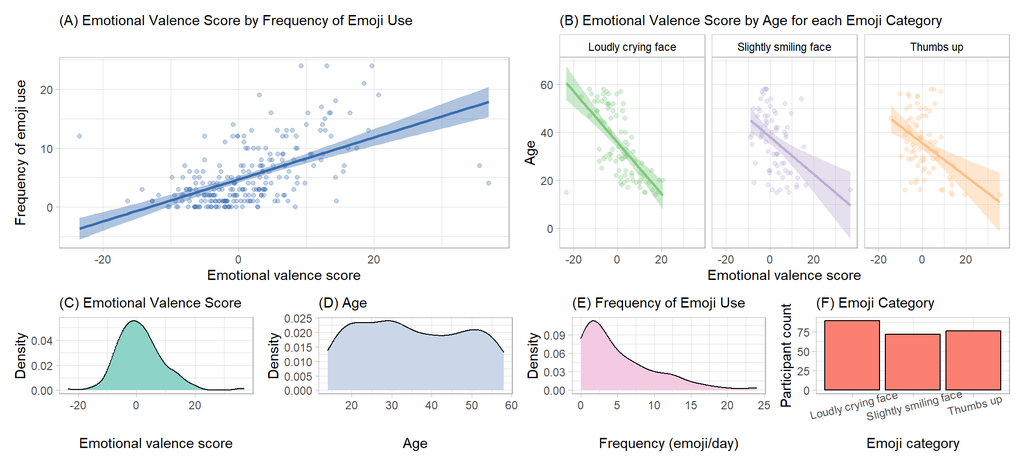

[figure not shown]

Figure 3.1: Relationships (A-B) and Marginal Distributions (C-F) of Variables of Interest for Emotional Effect

We conducted the following tests ($\alpha$ = .05) to address which factors influenced emotional valence score and how. Firstly, we conducted an analysis of variance (ANOVA) to test which predictors significantly improved model fit by significantly reducing sum of squared residuals according to an *F*-test. Then we examined the specific influences of age and its interaction with emoji category via the regression coefficients given the researchers’ interest in these. We evaluated these by their direction (i.e., how they influence emotional valence), estimate range (95 % confidence intervals), and significance with *t*-tests ($H_0: \hat\beta_i \neq 0$). Before performing these, we assessed if the fitted model complied with the assumptions of linear regression ($\varepsilon$ ~ $N(\frac{0}{var})$). Given the strong correlation between age and frequency of emoji use (see Correlation Between Age and Frequency of Emoji Use), we confirmed that multicollinarity, i.e., correlated predictors biasing model estimates, was negligible by estimating generalised variance inflation factors for each predictor (all below the a priori criterion of 5; see the Appendix Table 5.3). Heteroscedacity appeared unproblematic from a visual inspection the $\sqrt{standardised \ residuals}$ across fitted values (see Appendix, Figure 5.3C) although a Breusch-Pagan test indicated that residuals were significantly non-homoscestedastic ($\chi^2$ (1) = 12.87, *p* < 0.001). Likewise, a significant Shapiro-Wilks (*W* = 0.91, *p* < 0.001) indicated non-normal residuals, however, these seemed normally distributed (see Appendix, Figure 5.3B) except three outliers. Upon inspecting Cook’s distances, we identified and excluded three values exerting undue influence on model estimated coefficients (see Appendix, Figure 5.3 and Table 5.4; all above a priori threshold determined by $\frac{4}{N-k-1}$ = 0.02[^1]) as a sensitivity analysis (see Table 3.2) found changes to coefficient significances upon their removal. The residuals of the model fitted to this reduced dataset also complied to the assumptions of normality (as the excluded observations were also outliers in the Q-Q plot; *W* = 1, *p* = 0.67) and homoscedasticity ($\chi^2$ (1) = 0.24, *p* = 0.623 ).

Table 3.1: Emotional Effect of Emojis: Analysis of Variance Table (Sensitivity Analysis)

|  | Df | Sum of Squares | Mean Sum of Squares | F value | P value |
| --- | --- | --- | --- | --- | --- |
| Emoji usage | 1 | 93.84 | 93.84 | 172.89 | < 0.001 |
| Age | 1 | 0.66 | 0.66 | 1.22 | 0.271 |
| Emoji category | 2 | 1.97 | 0.98 | 1.81 | 0.166 |
| Age:Emoji category | 2 | 13.31 | 6.65 | 12.26 | < 0.001 |
| Residuals | 227 | 123.22 | 0.54 |  |  |

Table 3.2: Emotional Effect of Emojis Model

|  | Emotional Valence (Full Dataset Model) |  |  |  |  | Emotional Valence (Reduced Dataset Model |  |  |  |  |
| --- | --- | --- | --- | --- | --- | --- | --- | --- | --- | --- |
| Predictors | Estimates | std. Error | 95 % CI | t-statistic | p-value | Estimates | std. Error | 95 % CI | t-statistic | p-value |
| Intercept | -0.47 | 0.12 | -0.71 – -0.23 | -3.83 | **<0.001** | -0.60 | 0.11 | -0.81 – -0.38 | -5.46 | **<0.001** |
| Emoji use frequency | 0.08 | 0.02 | 0.04 – 0.11 | 4.57 | **<0.001** | 0.12 | 0.02 | 0.08 – 0.15 | 7.49 | **<0.001** |
| Age | -0.03 | 0.01 | -0.04 – -0.01 | -3.34 | **0.001** | -0.03 | 0.01 | -0.04 – -0.01 | -3.73 | **<0.001** |
| Emoji [🙂] | 0.21 | 0.13 | -0.04 – 0.47 | 1.63 | 0.105 | 0.11 | 0.12 | -0.13 – 0.34 | 0.89 | 0.374 |
| Emoji [👍] | 0.00 | 0.13 | -0.25 – 0.26 | 0.02 | 0.981 | -0.10 | 0.12 | -0.33 – 0.12 | -0.89 | 0.372 |
| Age:Emoji [🙂] | 0.02 | 0.01 | 0.00 – 0.04 | 2.18 | **0.030** | 0.04 | 0.01 | 0.02 – 0.06 | 4.39 | **<0.001** |
| Age:Emoji [👍] | 0.02 | 0.01 | -0.00 – 0.04 | 1.82 | 0.070 | 0.03 | 0.01 | 0.02 – 0.05 | 3.91 | **<0.001** |
| Observations | 237 |  |  |  |  | 234 |  |  |  |  |
| R<sup>2</sup> / R<sup>2</sup> adjusted | 0.340 / 0.323 |  |  |  |  | 0.471 / 0.457 |  |  |  |  |

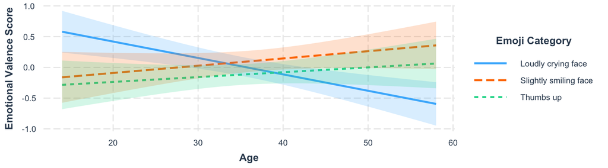

Figure 3.2: The interaction of Age and Emoji Category on the EVS

## 3.1 Conclusion

We investigated how emotional valence is affected by the age of participants after accounting for frequency of emoji use and whether this differed for different emojis. We found that for the loudly crying face emoji (😭), age negatively affected its emotional valence. We found nearly no change in the emotional valence of the other emoji categories. Thus, age affected emotional valence negatively only for some emoji.

# 4 Accuracy of Emoji Interpretation

Finally, we address what factors make participants more or less likely to correctly interpret emojis (according to the researchers’ coding scheme). The predictors of interest were the same as before; frequency of emoji use first to control for its known effect on interpreting emoji, and age and emoji category along with the interaction between these to investigate if there is an effect of age on interpretation accuracy and if this depends on the emoji. Figure 4.1 provides an overview of the marginal distribution of emoji interpretation accuracy (Figure 4.1C; see Figure 3.1 for marginal distributions of predictors) and its relationships with age by emoji category (Figure 4.1A) and for frequency of emoji use (Figure 4.1B). Generally, a slightly higher proportion of participants interpreted their emoji incorrectly - the thumbs up emoji (👍) seemed particularly hard to get correct while the louddly crying face emoji (😭) seemed to have a slightly higher proportion of correct responses (Figure 4.1C). Examining the median age and frequency in Figures 4.1A-B, it seems that incorrect responses are more common for older participants and for those who use emoji less frequently. Figure 4.1A provided some indication that the emoji being interpreted may moderate the relationship between lower age and correct interpretations - specifically, that the thumbs up emoji (👍) seem to have slightly lower median age for correct interpretations.

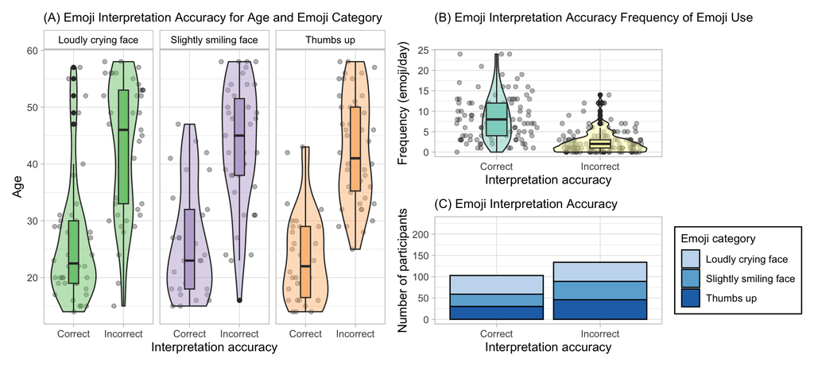

Figure 4.1: Relationships with Variables of Interest (A-B) and Marginal Distribution (C) for Interpretation Accuracy

Given the binary outcome (correct vs. incorrect interpretation; see Figure 4.1C), we fitted a multiple logistic regression model via maximum likelihood estimation. This estimates the change in log odds ratio of correct interpretation for changes in each predictor (see eq. (4.1)). We included the predictors as outlined above. Like the previous model, we mean-centered age so that the log odds of the intercept were estimated for the mean age of the sample rather than extrapolated to age 0. We treatment coded emoji category with the loudly crying face emoji (😭) as the reference level (coding scheme in the Appendix, Table 5.2). This provides two dummy coded variables ($D_1$ and $D2$ in eq. (4.1)) representing the mean difference in log odds of successful interpretation between this reference level and each of the slightly smiling face emoji (🙂) and the thumbs up emoji (👍). Thus, we fitted a model where the intercept was the log odds ratio of correctly interpreting a loudly crying face emoji (😭) for a mean-aged participant reporting using 0 emoji/day. Equation (4.1) shows the exact model fitted:

$$\begin{align}
\log[ \frac {P(Correct)}{P(Incorrect)}] = & \ \hat\beta_0 + \hat\beta_{1}(Frequency) + \hat\beta_{2}(Age) + \hat\beta_{3}D_{1[slightly \ smiling \ face]} + \hat\beta_{4}D_{2[thumbs \ up]} \ + \\
& \ \hat\beta_{5}(Age · D_{1[slightly \ smiling \ face]}) + \hat\beta_{6}(Age · D_{2[thumbs \ up]}) \tag{4.1}
\end{align}$$

As shown in Table 4.1, likelihood ratio tests indicated that age significantly improved model fit above and beyond what frequency of emoji use alone could account for ($\chi^2$(1) = 24.04, *p* < 0.001). The interaction between age and emoji category further significantly reduced deviance of the model ($\chi^2$(2) = 7.12, *p* = 0.028) although inclusion of emoji category alone did not affect model deviance ($\chi^2$(2) = 1.91, *p* = 0.385). Thus, age and its interaction with emoji category, each significantly contributed to improving predicted interpretation accuracy beyond what could be accounted for by frequency of emoji use.

Table 4.1: Emoji Interpretation: Analysis of Deviance Table

|  | Df | Deviance | Residual Df | Residual Deviance | p-value |
| --- | --- | --- | --- | --- | --- |
| Intercept-only |  |  | 236 | 324.49 |  |
| Emoji use frequency | 1 | 96.51 | 235 | 227.97 | < 0.001 |
| Age | 1 | 24.04 | 234 | 203.94 | < 0.001 |
| Emoji category | 2 | 1.91 | 232 | 202.03 | 0.385 |
| Age:Emoji category | 2 | 7.12 | 230 | 194.91 | 0.028 |

Table 4.2: Interpretation Accuracy Model

|  | Correct Emoji Interpretation |  |  |  |  |
| --- | --- | --- | --- | --- | --- |
| Predictors | Odds Ratio | std. Error | 95 % CI | z-statistic | p-value |
| Intercept | 0.52 | 0.21 | 0.24 – 1.12 | -1.65 | 0.098 |
| Emoji use frequency | 1.12 | 0.08 | 0.99 – 1.29 | 1.68 | 0.092 |
| Age | 0.92 | 0.03 | 0.87 – 0.97 | -2.83 | **0.005** |
| Emoji [🙂] | 0.67 | 0.28 | 0.29 – 1.51 | -0.97 | 0.333 |
| Emoji [👍] | 0.34 | 0.18 | 0.11 – 0.91 | -2.02 | **0.044** |
| Age:Emoji [🙂] | 0.98 | 0.04 | 0.91 – 1.05 | -0.54 | 0.588 |
| Age:Emoji [👍] | 0.86 | 0.06 | 0.74 – 0.97 | -2.20 | **0.028** |
| Observations | 237 |  |  |  |  |
| Deviance | 194.912 |  |  |  |  |
| log-Likelihood | -97.456 |  |  |  |  |

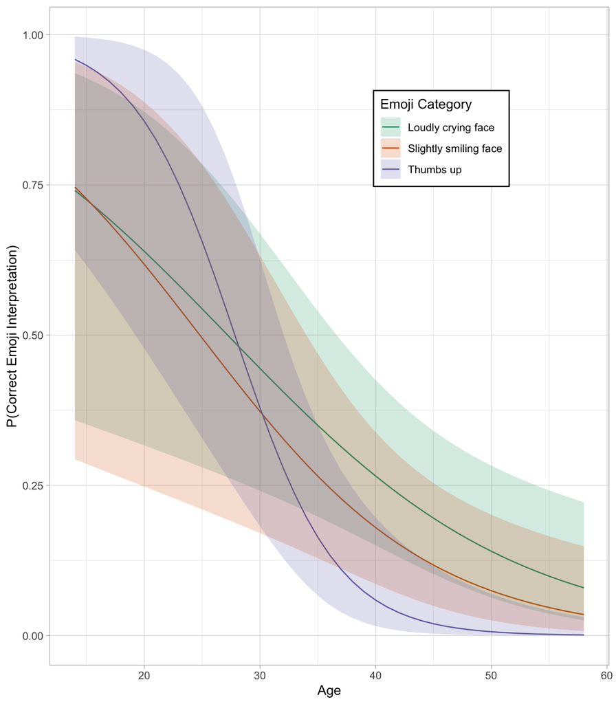

Figure 4.2: Predicted Probability of Correct Emoji Interpretation Age for Each Emoji Tested

Figure 4.2 visualises the predicted probability of correctly interpreting emoji for the age by emoji category interaction; the probability of accurately interpreting the emoji for the sample age range, split by each emoji category, and holding frequency of emoji use constant (at 0). Emphasising the results of the regression coefficients, the probability of correctly interpreting the thumbs up emoji (👍) seem to change more with age than the other emoji categories. Although as shown by the overlapping uncertainty ranges, the predicted effects may also be very similar for most ages.

## 4.2 Conclusion

We found that older age decreased how likely participants were to interpret emoji correctly. Although the extent of this was moderated by the emoji being interpreted. The thumbs up emoji (👍) had a generally lower likelihood of being interpreted correctly and this decreased more in older participants than the other emojis in the study. In short, age seem to have a negative impact on how emojis are interpreted although the extent of this depends on the emoji.

# 5 Appendix: Supplementary Tables and Figures

## 5.1 Data Preparation

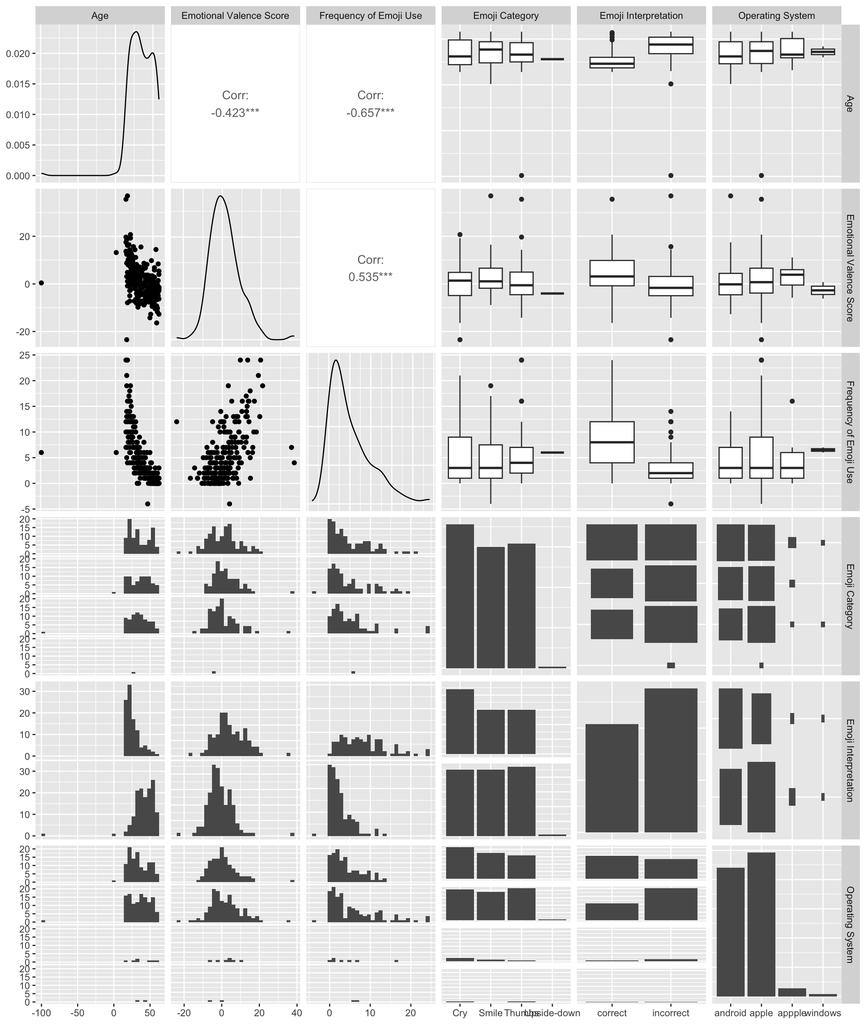

Figure 5.1: Marginal Distributions and Between-Variable Relationships for Pre-Processed Data

Table 5.1: Excluded Observations

| Name | Age | Operating system | Emoji use frequency | Emoji category | Emotional valence score | Emoji Interpretation | Reason for exlcusion |
| --- | --- | --- | --- | --- | --- | --- | --- |
| Beatrix Potter | 28 | Apple | 6 | upside-down face | -4.02 | incorrect | Emoji not in study materials is reported |
| Thomas Burnet | 1 | Android | 6 | slightly smiling face | 13.17 | incorrect | Impossible or unlikely age |
| Joseph Priestley | NA | Apple | 10 | slightly smiling face | -1.17 | correct | Age is missing |
| Robert Bunsen | -99 | Apple | 6 | thumbs up | 0.43 | incorrect | Impossible or unlikely age |
| Luigi Galvani | 43 | Apple | -4 | slightly smiling face | 3.71 | incorrect | Impossible frequency value (negative) is reported |

## 5.2 Data Description

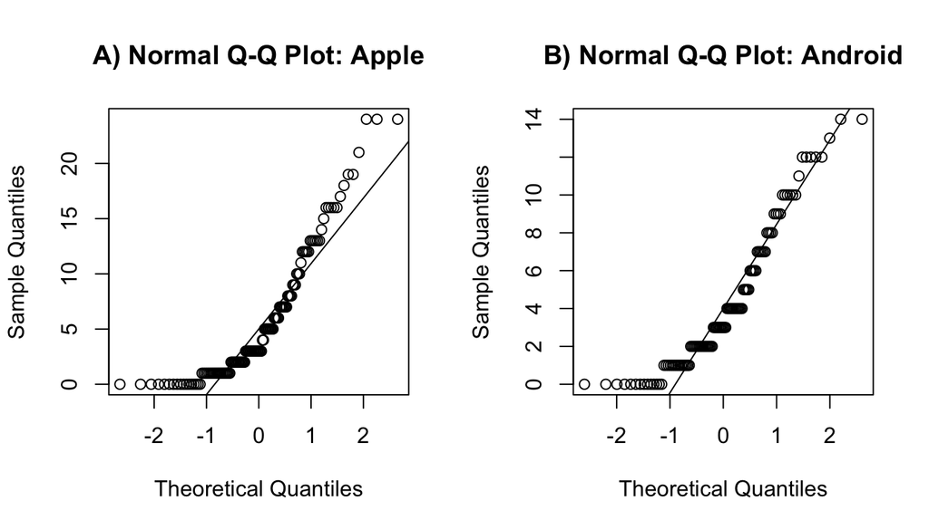

Figure 5.2: QQPlots of Frequency of Emoji for (A) Apple and (B) Android Users

## 5.3 The Emotional Effect of Emojis

Table 5.2: Emoji Category Treatment Contrast Coding Scheme

|  | D1 | D2 |
| --- | --- | --- |
| Loudly crying face | 0 | 0 |
| Slightly smiling face | 1 | 0 |
| Thumbs up | 0 | 1 |

Table 5.3: Variance Inflation Factors for Predictors of Emotional Effect

|  | GVIF | Df |
| --- | --- | --- |
| Emoji use frequency | 2.61 | 1 |
| Age | 3.89 | 1 |
| Emoji category | 1.01 | 2 |
| Age:Emoji category | 2.45 | 2 |

Table 5.4: Influence Measures for Potentially Influential Values

|  | DFBeta intercept | DFBeta frequency | DFBeta age | DFBeta Emoji [🙂] | DFBeta Emoji [👍] | DFBeta age:Emoji [🙂] | DFBeta age:Emoji [👍] | DFFit | Covariance ratio | Cook’s Distance | Hat values |
| --- | --- | --- | --- | --- | --- | --- | --- | --- | --- | --- | --- |
| 2 | -0.31 | -0.13 | 0.58 | 0.38 | 0.38 | -0.55 | -0.54 | -1.03 | 0.46 | 0.13 | 0.03 |
| 13 | 0.65 | -0.93 | -0.57 | 0.64 | 0.01 | -0.89 | -0.04 | 1.62 | 0.41 | 0.33 | 0.07 |
| 175 | 0.39 | -0.55 | -0.34 | 0.02 | 0.46 | -0.02 | -0.84 | 1.36 | 0.47 | 0.24 | 0.06 |

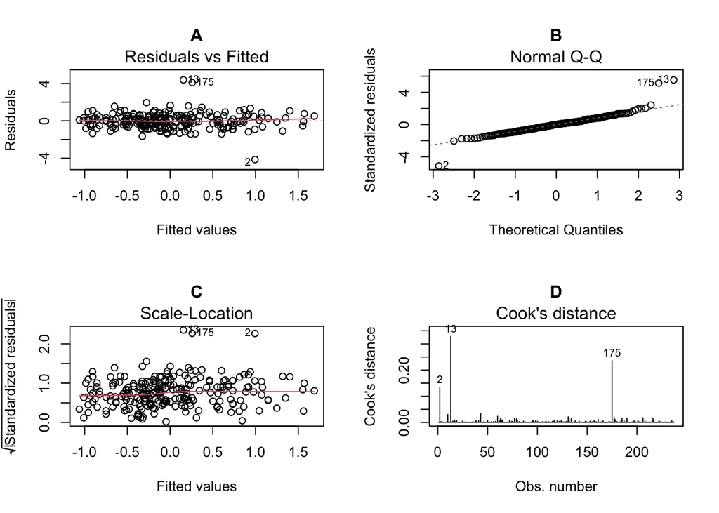

Figure 5.3: Assumptions for Linear Regression Model

## 5.4 Accuracy of Emoji Interpretation

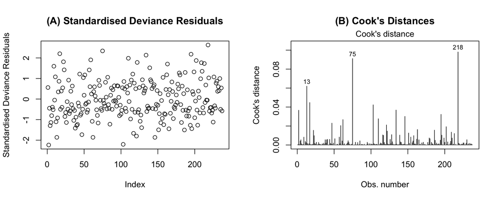

Figure 5.4: (A) Standardised Deviance Residuals and (B) Cook’s Distances for the Interpretation Accuracy Model

Table 5.5: Variance Inflation Factors for Predictors of Interpretation Accuracy

|  | GVIF | Df |
| --- | --- | --- |
| Emoji use frequency | 2.05 | 1 |
| Age | 2.65 | 1 |
| Emoji category | 1.44 | 2 |
| Age:Emoji category | 2.42 | 2 |

Table 5.6: Influence Measures for Potentially Influential Values

|  | DFBeta intercept | DFBeta frequency | DFBeta age | DFBeta Emoji [🙂] | DFBeta Emoji [👍] | DFBeta age:Emoji [🙂] | DFBeta age:Emoji [👍] | DFFit | Covariance ratio | Cook’s Distance | Hat values |
| --- | --- | --- | --- | --- | --- | --- | --- | --- | --- | --- | --- |
| 13 | -0.27 | 0.37 | 0.22 | -0.18 | 0.02 | 0.40 | 0.00 | -0.65 | 1.00 | 0.06 | 0.09 |
| 75 | -0.13 | 0.18 | 0.11 | -0.01 | 0.42 | 0.01 | 0.44 | 0.56 | 0.89 | 0.09 | 0.05 |
| 218 | 0.02 | -0.03 | -0.02 | 0.00 | 0.34 | 0.00 | 0.38 | 0.45 | 0.82 | 0.10 | 0.02 |

Table 5.7: Potentially Influential Observations

[output not shown]

Table 5.8: Emoji Interpretation: Analysis of Deviance Table (Sensitivity Analysis 1)

|  | Df | Deviance | Res. Df | Res. Deviance | p-value |
| --- | --- | --- | --- | --- | --- |
| Intercept-only |  |  | 234 | 321.13 |  |
| Frequency | 1 | 98.08 | 233 | 223.05 | < 0.001 |
| Age | 1 | 25.76 | 232 | 197.29 | < 0.001 |
| Emoji | 2 | 2.96 | 230 | 194.34 | 0.228 |
| Age:Emoji | 2 | 15.32 | 228 | 179.01 | < 0.001 |

Table 5.8: Emoji Interpretation: Analysis of Deviance Table (Sensitivity Analysis 2)

|  | Df | Deviance | Res. Df | Res. Deviance | p-value |
| --- | --- | --- | --- | --- | --- |
| Intercept-only |  |  | 235 | 323.34 |  |
| Frequency | 1 | 96.28 | 234 | 227.06 | < 0.001 |
| Age | 1 | 26.86 | 233 | 200.20 | < 0.001 |
| Emoji | 2 | 1.82 | 231 | 198.38 | 0.403 |
| Age:Emoji | 2 | 7.02 | 229 | 191.36 | 0.03 |

Table 5.9: Table of Coefficients for the Reported Model and Sensitivity Analyses for Emoji Interpretation Accuracy

|  | Reported model |  |  |  |  | Sensitivity Analysis 1 |  |  |  |  | Sensitivity Analysis 2 |  |  |  |  |
| --- | --- | --- | --- | --- | --- | --- | --- | --- | --- | --- | --- | --- | --- | --- | --- |
| Predictors | Odds Ratio | std. Error | 95 % CI | z-statistic | p-value | Odds Ratio | std. Error | 95 % CI | z-statistic | p-value | Odds Ratio | std. Error | 95 % CI | z-statistic | p-value |
| Intercept | 0.52 | 0.21 | 0.24 – 1.12 | -1.65 | 0.098 | 0.56 | 0.22 | 0.25 – 1.21 | -1.47 | 0.142 | 0.58 | 0.23 | 0.26 – 1.26 | -1.36 | 0.174 |
| Emoji use frequency | 1.12 | 0.08 | 0.99 – 1.29 | 1.68 | 0.092 | 1.10 | 0.08 | 0.97 – 1.27 | 1.43 | 0.152 | 1.09 | 0.08 | 0.96 – 1.26 | 1.29 | 0.196 |
| Age | 0.92 | 0.03 | 0.87 – 0.97 | -2.83 | **0.005** | 0.92 | 0.03 | 0.87 – 0.97 | -2.91 | **0.004** | 0.92 | 0.03 | 0.86 – 0.97 | -3.00 | **0.003** |
| Emoji [🙂] | 0.67 | 0.28 | 0.29 – 1.51 | -0.97 | 0.333 | 0.67 | 0.28 | 0.29 – 1.52 | -0.95 | 0.340 | 0.72 | 0.31 | 0.31 – 1.66 | -0.77 | 0.443 |
| Emoji [👍] | 0.34 | 0.18 | 0.11 – 0.91 | -2.02 | **0.044** | 0.09 | 0.08 | 0.01 – 0.41 | -2.61 | **0.009** | 0.34 | 0.18 | 0.11 – 0.90 | -2.04 | **0.042** |
| Age:Emoji [🙂] | 0.98 | 0.04 | 0.91 – 1.05 | -0.54 | 0.588 | 0.98 | 0.04 | 0.91 – 1.05 | -0.56 | 0.576 | 0.96 | 0.04 | 0.89 – 1.04 | -0.91 | 0.365 |
| Age:Emoji [👍] | 0.86 | 0.06 | 0.74 – 0.97 | -2.20 | **0.028** | 0.71 | 0.10 | 0.49 – 0.88 | -2.46 | **0.014** | 0.86 | 0.06 | 0.74 – 0.97 | -2.20 | **0.028** |
| Observations | 237 |  |  |  |  | 235 |  |  |  |  | 236 |  |  |  |  |
| Deviance | 194.912 |  |  |  |  | 179.015 |  |  |  |  | 191.364 |  |  |  |  |
| log-Likelihood | -97.456 |  |  |  |  | -89.507 |  |  |  |  | -95.682 |  |  |  |  |

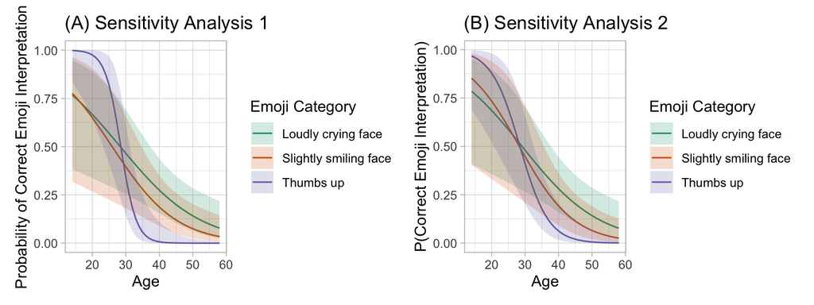

Figure 5.5: Predicted Probability of Correct Emoji Interpretation Age for Each Emoji Tested for (A) Sensitivity Analysis 1 and (B) Sensitivity Analysis 2

[^1]: where *N* is the number of observations (237) and *k* is the number of model predictors (4)
[^2]: Note, that this discrepancy of significance for the frequency of emoji use between the analysis of deviance and logistic regression coefficient may be related to how much it uniquely reduces model deviance and its correlation with age. Specifically, it may share a large amount of the reduced deviance with age due to their correlation - thus, in the analysis of deviance due to its antecedency this overlap was attributed to it, yet, in the linear model only non-overlapping deviance is considered. This also suggests that age has a sizable unique impact on deviance compared to frequency.